# Big Match - Skill Identification and Analysis

- Professional Matching
- Expert Finding
- Skill Trend Analysis

## Exploring Data-Source: Stack Exchange

- About Stack Exchange https://stackexchange.com/about
- All Communities https://stackexchange.com/sites
- Map of Developers Viewing Stack Overflow Q&A in Real Time https://talent.stackoverflow.com/about-targeting

### Getting the data

- API
  - https://api.stackexchange.com/
- Periodic Data dumps
  - https://ia800500.us.archive.org/22/items/stackexchange/readme.txt

### The database schema

[figure not shown]

We analysed **Stackoverflow.com** community data until June 3 2019. In total there are 8 xml files with the following names:

1. Users.xml
2. Tags.xml
3. Votes.xml
4. Posts.xml
5. PostsLinks.xml
6. PostHistory.xml
7. Comments.xml
8. Badges.xml

```python
import subprocess
import pymongo
import datetime
import os, sys
import matplotlib.pyplot as plt
import numpy as np
sys.path.append('..')
p = subprocess.Popen('ls -lh data/stackoverflow/', shell=True, stdout=subprocess.PIPE, stderr=subprocess.STDOUT)
for line in p.stdout.readlines():
    if line.__contains__(b".xml"):
        print(line)
retval = p.wait()
```

```
b'-rw-r--r--@ 1 skenderi  1905347040   3.5G Jun  3 04:59 Badges.xml\n'
b'-rw-r--r--@ 1 skenderi  1905347040    18G Jun  3 05:09 Comments.xml\n'
b'-rw-r--r--@ 1 skenderi  1905347040   691M Jun  3 06:55 PostLinks.xml\n'
b'-rw-r--r--@ 1 skenderi  1905347040    68G Jun  3 06:55 Posts.xml\n'
b'-rw-r--r--@ 1 skenderi  1905347040   4.7M Jun  3 06:55 Tags.xml\n'
b'-rw-r--r--@ 1 skenderi  1905347040   3.2G Jun  3 06:57 Users.xml\n'
b'-rw-r--r--@ 1 skenderi  1905347040    16G Jun  3 07:08 Votes.xml\n'
b'-rw-r--r--@ 1 skenderi  1905347040   1.1K Sep  6 22:26 post.xml\n'
```

### Data stats:

- 10.528.667 **Users**
- 138.577 **Tags**
- 187.950.517 **Votes**
- 44.945.360 **Posts** (2.007.633 from Jan '19)
- 5.901.340 **PostsLinks**
- {not extracted} **PostHistory**
- 99.422.949 **Comments**
- 32.712.058 **Badges**

```python
dbm = pymongo.MongoClient()['stackexchange_demo']
#List of fields/attributes we get for each post
for field in dbm.posts.find_one():
    print(field)
```

```
_id
@Id
@PostTypeId
@AcceptedAnswerId
@CreationDate
@Score
@ViewCount
@Body
@OwnerUserId
@LastEditorUserId
@LastEditorDisplayName
@LastEditDate
@LastActivityDate
@Title
@Tags
@AnswerCount
@CommentCount
@FavoriteCount
@CommunityOwnedDate
```

```python
post_filter = {'@CreationDate' : {'$gt':'2019'}}
posts = dbm.posts.find(post_filter)
all_tags, all_locations = {}, {}
location_nan, tags_nan = 0, 0
for post in posts:
    if '@OwnerLocation' in post:
        location = post['@OwnerLocation']
        if location in all_locations:
            all_locations[location] += 1
        else:
            all_locations[location] = 1
    else:
        location_nan += 1
    if '@Tags' in post:
        tags = post['@Tags']
        for tag in tags:
            if tag in all_tags and type(all_tags) != type("") and len(str(tag))>2:
                all_tags[tag] += 1
            else:
                all_tags[tag] = 1
    else:
        tags_nan += 1
```

```python
#Print top 20 most frequent post tags
for t in sorted(all_tags.items(), key=lambda x: x[1], reverse=True)[:20]:
    print(t)
```

```
('python', 45169)
('javascript', 44284)
('java', 30840)
('android', 23770)
('php', 19856)
('html', 16102)
('reactjs', 13865)
('angular', 13129)
('python-3.x', 13112)
('node.js', 12847)
('css', 10788)
('c++', 10015)
('sql', 9310)
('jquery', 9298)
('mysql', 9136)
('ios', 8644)
('swift', 8268)
('pandas', 7071)
('typescript', 7059)
('django', 6994)
```

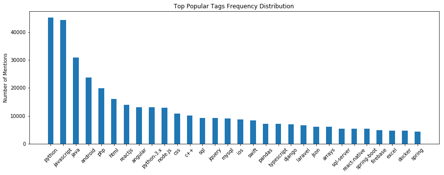

```python
# #Histogram of all tags
sub_tags = sorted(all_tags.items(), key=lambda x: x[1], reverse=True)[:30]
vals, labels = [], []
for p in sub_tags:
    vals.append(p[1])
    labels.append(p[0])

x = np.arange(len(labels))  # the label locations
width = 0.45  # the width of bars

fig, ax = plt.subplots()
fig.set_figheight(5)
fig.set_figwidth(15)
rects1 = ax.bar(x , vals, width, label=labels)
# rects2 = ax.bar(x + width/2, dist_b, width, label=location_b)

# Adding labels
ax.set_ylabel('Number of Mentions')
ax.set_title("Top Popular Tags Frequency Distribution")
ax.set_xticks(x)

plt.xticks(rotation=45)
ax.set_xticklabels(labels)
plt.show()
```

```python
#Print top 20 most frequent post-owner locations
for l in sorted(all_locations.items(), key=lambda x: x[1], reverse=True)[:20]:
    print(l)
```

```
('India', 10838)
('Bangalore, Karnataka, India', 8370)
('Germany', 6936)
('Pune, Maharashtra, India', 4727)
('Chennai, Tamil Nadu, India', 3961)
('France', 3861)
('Hyderabad, Telangana, India', 3829)
('London, UK', 3301)
('Israel', 3286)
('Paris, France', 3197)
('Mumbai, Maharashtra, India', 3183)
('USA', 3117)
('United States', 3114)
('Bengaluru, Karnataka, India', 3038)
('London, United Kingdom', 2961)
('United Kingdom', 2673)
('Canada', 2481)
('Philippines', 2390)
('Singapore', 2388)
('Netherlands', 2346)
```

```python
dbm = pymongo.MongoClient()['stackexchange_demo']

def plot_tag_pop(tag="", location_a="", location_b=""):
    post_filter = {'@CreationDate' : {'$gt':'2019'},
                   '@Tags' : tag,
                   '$or' : [{'@OwnerLocation':{'$regex':'.*'+location_a+'.*'}},
                            {'@OwnerLocation':{'$regex':'.*'+location_b+'.*'}}]}
    posts = list(dbm.posts.find(post_filter))
    print("Posts in total:", len(posts))
    max_weeks = 22
    dist_a = [0 for _ in range(max_weeks)]
    dist_b = [0 for _ in range(max_weeks)]
    for post in posts:
        creation_date = datetime.datetime.strptime(post['@CreationDate'].split('T')[0], '%Y-%m-%d')
        creation_week = creation_date.date().isocalendar()[1]

        if post['@OwnerLocation'].__contains__(location_a):
            dist_a[creation_week -1] += 1
        else:
            dist_b[creation_week -1] += 1

    labels = ["w{}".format(x) for x in range(1, max_weeks+1)]

    x = np.arange(len(labels))  # the label locations
    width = 0.45  # the width of bars

    fig, ax = plt.subplots()
    fig.set_figheight(5)
    fig.set_figwidth(15)
    rects1 = ax.bar(x - width/2, dist_a, width, label=location_a)
    rects2 = ax.bar(x + width/2, dist_b, width, label=location_b)

    # Adding labels
    ax.set_ylabel('# of posts')
    ax.set_title("Posts related to the tag '{}'".format(tag))
    ax.set_xticks(x)
    ax.set_xticklabels(labels)
    ax.legend()

    def autolabel(rects):
        for rect in rects:
            height = rect.get_height()
            ax.annotate('{}'.format(height),
                        xy=(rect.get_x() + rect.get_width() / 2, height),
                        xytext=(0, 2),  # 2 points vertical offset
                        textcoords="offset points",
                        ha='center', va='bottom')
    autolabel(rects1)
    autolabel(rects2)
    fig.tight_layout()
    plt.show()
```

```
Posts in total: 11999
```

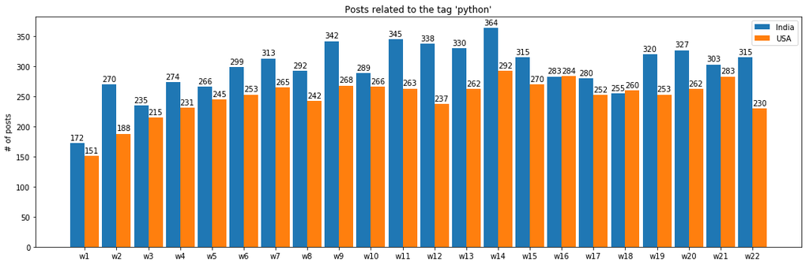

```python
plot_tag_pop(tag="python", location_a="India", location_b="USA")
```

```
Posts in total: 370
```

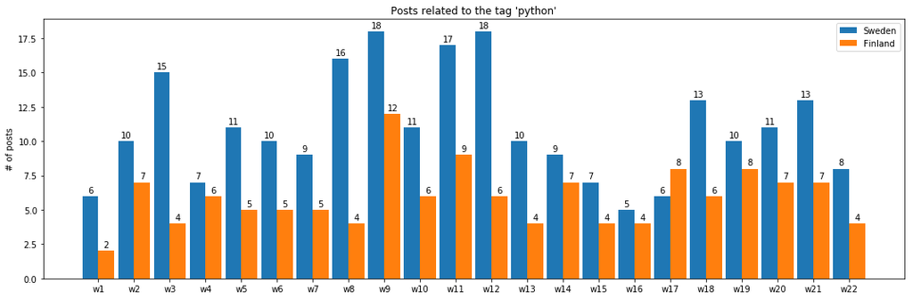

```python
plot_tag_pop(tag="python", location_a="Sweden", location_b="Finland")
```

```python
def plot_tag_feedback(tag=""):
    post_filter = {'@CreationDate' : {'$gt':'2019'},
                   '@Tags' : tag
                  }
    posts = list(dbm.posts.find(post_filter))
    print("Posts in total:", len(posts))
    max_weeks = 22
    post_cnt = [0 for _ in range(max_weeks)]
    answers = [0 for _ in range(max_weeks)]
    favorite = [0 for _ in range(max_weeks)]
    for post in posts:
        creation_date = datetime.datetime.strptime(post['@CreationDate'].split('T')[0], '%Y-%m-%d')
        creation_week = creation_date.date().isocalendar()[1]

        post_cnt[creation_week -1] += 1
        if '@CommentCount' in post:
            answers[creation_week -1] += int(post['@CommentCount'])
        if '@FavoriteCount' in post:
            favorite[creation_week -1] += int(post['@FavoriteCount'])

    labels = ["w{}".format(x) for x in range(1, max_weeks+1)]

    x = np.arange(len(labels))  # the label locations
    width = 0.45  # the width of bars

    fig, ax = plt.subplots()
    fig.set_figheight(5)
    fig.set_figwidth(15)
    rects1 = ax.bar(x - width/2, post_cnt, width/2, label='Num. of posts')
    rects2 = ax.bar(x , answers, width/2, label='AnswerCount')
    rects3 = ax.bar(x + width/2, favorite, width/2, label='FavoriteCount')

    # Add some text for labels, title and custom x-axis tick labels, etc.
    ax.set_ylabel('# of posts')
    ax.set_title("Feedback related to the tag '{}'".format(tag))
    ax.set_xticks(x)
    ax.set_xticklabels(labels)
    ax.legend()

    def autolabel(rects):
        for rect in rects:
            height = rect.get_height()
            ax.annotate('{}'.format(height),
                        xy=(rect.get_x() + rect.get_width() / 2, height),
                        xytext=(0, 2),  # 3 points vertical offset
                        textcoords="offset points",
                        ha='center', va='bottom')
    autolabel(rects1)
    autolabel(rects2)
    autolabel(rects3)
    fig.tight_layout()
    plt.show()
```

```
Posts in total: 45169
```

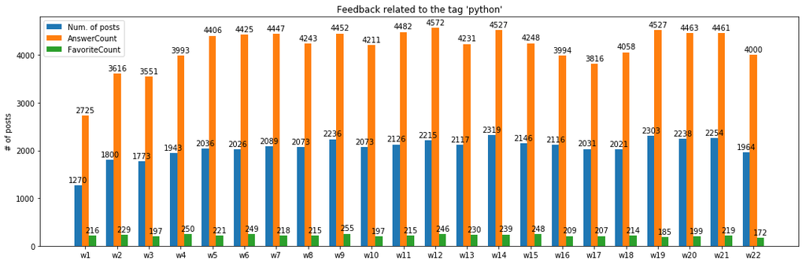

```python
plot_tag_feedback('python')
```

```
Posts in total: 9136
```

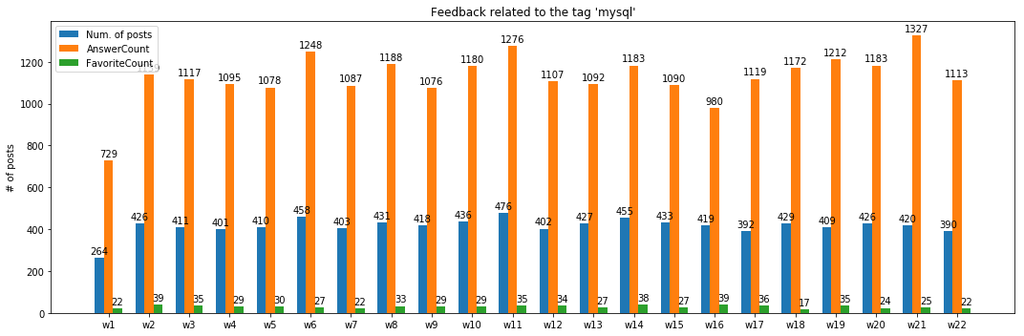

```python
plot_tag_feedback('mysql')
```

```
Posts in total: 44284
```

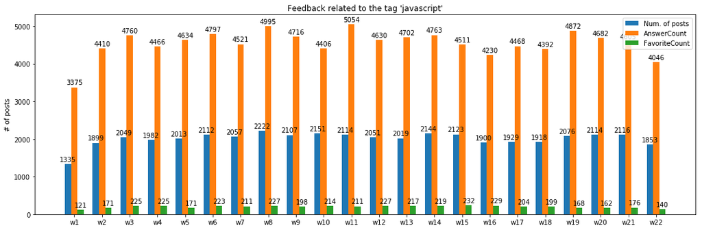

```python
plot_tag_feedback('javascript')
```

## Potential Use Cases:

### Use Case 1: Question Recommender System

**Description:**

- Recommend questions to experts/users who have a better chance to know a better answer.

**StackExchange question-related rules:**

- User should only ask practical, answerable questions.
- No Open-Ended questions allowed.
- Every user can ask questions regardless of their reputation

**Basic Methodology:**

- Represent every expert user with her set of answers/questions/comments.
- Run content-similarity techniques between the question's content and each expert's set.

### Use Case 2: Trends For You

[figure not shown]

**Description:**

- Recommend topics (i.e tags) that are getting increasing attention.

**StackExchange tag-related rules:**

- A tag is a word or phrase that describes the topic of the question.
- Tags are a means of connecting experts with questions.
- New users are not allowed to create new tags.
- Each question may only contain 5 tags max.
- Users may suggest edits or directly edit the tags of a question.

**Basic Methodology:**

- Train a machine learning classifier to detect tag-hypes based on a specific tag's popularity trend-line

```python
print("Thank you")
```

```
Thank you
```